*EXECUTIVE SUMMARY*

This report aims at investigating the following questions:

1. Is an automatic or manual transmission better for MPG (miles per gallons)
2. Quantify the MPG difference between automatic and manual transmissions

The analysis is carried out on the dataset mtcars. Due to the small number of models and the age of the dataset, the results cannot be generalised to the current population of cars, but can give an insight within the set of cars considered.

The sole distinction between manual and automatic cars is a poor predictor of the fuel consumption and other factors more influential have to be taken into account in a more precise prediction. The other reason we need to consider other factors is that in the database, manual cars tend to be imported models generally lighter and smaller, hence with lower fuel consumption.

To better answer the question we therefore propose a model to predict fuel consumption which includes, on top of the a/m distinction, the weight of the car and the number of cylinders. In this context, there is not a statistically significant difference in fuel consumption between manual cars and automatic ones.

*REPORT*

The database contains 32 car models of which 19 have automatic transmission and 13 have manual. The variable “am” is 0 for automatic transmission and 1 for manual.

A simple t-test confirm that the two transmissions are not from the same population as the interval does not contain 0 and the p-value 0.0013736 is sufficiently low (see appendix 2). For the sake of this projects we assume “mpg” to have a normal distribution, although it looks a little skewed.

We consider a linear model with “am” as a predictor and “mpg” as a response. The relatevly high F-statistic and the very low p-value confirm that there might be a correlation, but if we look at how well the model fit, R-squared *0.36* is very low (1 being best fit, 0 being no fit at all). This, together with a Residual Standard Error (RSE) of *4.822*, suggests that the model is not very accurate and that there might be other model to better explain the correlation.

A look at the “wt” plot of Appendix 1 suggests that manuals cars in the database are generally lighter. In Appendix 3, we plot the two different regression lines for manual cars (in red) and automatic (in black) with “wt” as predictor and “mpg” as an outcome. From the graph it seems that weight affects manual trasmission more than automatic transmission. Based on literature review we disregard this hypothesis and we suggest that this is due to “wt” being a quadratic predictor of “mpg” (that is, the first tons impact fuel consumption more than farther ones) and manual/lighter cars of this dataset, being in the left part of the graph, have a quicker decline in performance than automatic ones when weight increases. Indeed a linear model with a quadratic predictor better explain the relationship between “wt” and “mpg”, as the R-squared goes from *0.75* to *0.82* with a reduced RSE from *3.05* to *2.65* and improved p-value (see appendix 4)

The third model includes cyinders, weight, manual/automatic transmission and the interaction between the latter and the weight

Last, we add the variables “drat” and the interaction between “disp” and “cyl”.

We can now run an anova test to verify which of these variale can be dropped without loss of relevant information.

```
## Analysis of Variance Table
##
## Model 1: mpg ~ wt
## Model 2: mpg ~ wt + I(wt^2)
## Model 3: mpg ~ wt + I(wt^2) + cyl
## Model 4: mpg ~ wt + I(wt^2) + cyl + am + wt:am
## Model 5: mpg ~ wt + I(wt^2) + cyl + am + drat + wt:am
## Model 6: mpg ~ wt + I(wt^2) + cyl + am + drat + wt:am + cyl:disp
##   Res.Df    RSS Df Sum of Sq       F   Pr(>F)
## 1     30 278.32
## 2     29 203.75  1    74.576 13.0317 0.001402 **
## 3     28 160.53  1    43.214  7.5513 0.011200 *
## 4     26 137.54  2    22.987  2.0084 0.156137
## 5     25 137.54  1     0.007  0.0012 0.972920
## 6     24 137.34  1     0.192  0.0336 0.856044
## ---
## Signif. codes:  0 '***' 0.001 '**' 0.01 '*' 0.05 '.' 0.1 ' ' 1
```

*APPENDIX* Appendix 1 Exploratory graphs

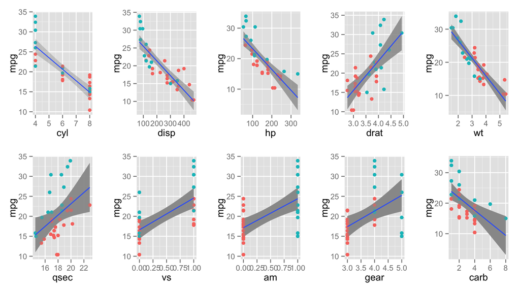

Appendix 2

```
##
##  Welch Two Sample t-test
##
## data:  mtcars$mpg by mtcars$am
## t = -3.7671, df = 18.332, p-value = 0.001374
## alternative hypothesis: true difference in means is not equal to 0
## 95 percent confidence interval:
##  -11.280194  -3.209684
## sample estimates:
## mean in group 0 mean in group 1
##        17.14737        24.39231
```

Appendix 3

```
##              Estimate Std. Error   t value     Pr(>|t|)
## (Intercept) 31.416055  3.0201093 10.402291 4.001043e-11
## am          14.878423  4.2640422  3.489277 1.621034e-03
## wt          -3.785908  0.7856478 -4.818836 4.551182e-05
## am:wt       -5.298360  1.4446993 -3.667449 1.017148e-03
```

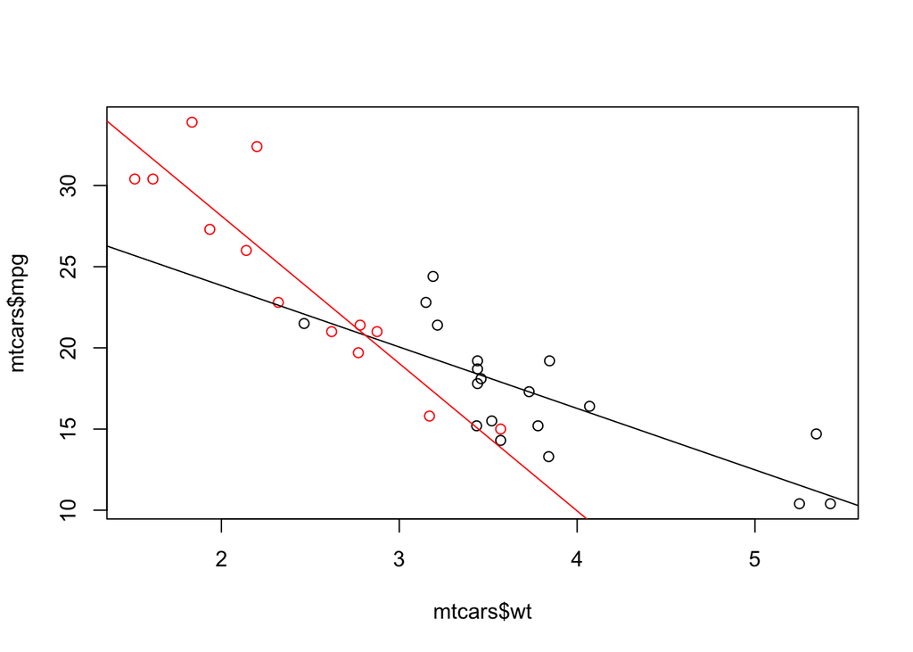

Appendix 4

```
##
## Call:
## lm(formula = mpg ~ wt, data = mtcars)
##
## Residuals:
##     Min      1Q  Median      3Q     Max
## -4.5432 -2.3647 -0.1252  1.4096  6.8727
##
## Coefficients:
##             Estimate Std. Error t value Pr(>|t|)
## (Intercept)  37.2851     1.8776  19.858  < 2e-16 ***
## wt           -5.3445     0.5591  -9.559 1.29e-10 ***
## ---
## Signif. codes:  0 '***' 0.001 '**' 0.01 '*' 0.05 '.' 0.1 ' ' 1
##
## Residual standard error: 3.046 on 30 degrees of freedom
## Multiple R-squared:  0.7528, Adjusted R-squared:  0.7446
## F-statistic: 91.38 on 1 and 30 DF,  p-value: 1.294e-10
```

```
##
## Call:
## lm(formula = mpg ~ wt + I(wt^2), data = mtcars)
##
## Residuals:
##    Min     1Q Median     3Q    Max
## -3.483 -1.998 -0.773  1.462  6.238
##
## Coefficients:
##             Estimate Std. Error t value Pr(>|t|)
## (Intercept)  49.9308     4.2113  11.856 1.21e-12 ***
## wt          -13.3803     2.5140  -5.322 1.04e-05 ***
## I(wt^2)       1.1711     0.3594   3.258  0.00286 **
## ---
## Signif. codes:  0 '***' 0.001 '**' 0.01 '*' 0.05 '.' 0.1 ' ' 1
##
## Residual standard error: 2.651 on 29 degrees of freedom
## Multiple R-squared:  0.8191, Adjusted R-squared:  0.8066
## F-statistic: 65.64 on 2 and 29 DF,  p-value: 1.715e-11
```

```
## [1] -0.6924953
```

```
##
##  Welch Two Sample t-test
##
## data:  wt[am == 0] and wt[am == 1]
## t = 5.4939, df = 29.234, p-value = 6.272e-06
## alternative hypothesis: true difference in means is not equal to 0
## 95 percent confidence interval:
##  0.8525632 1.8632262
## sample estimates:
## mean of x mean of y
##  3.768895  2.411000
```

```
##
## Call:
## lm(formula = wt ~ am)
##
## Residuals:
##     Min      1Q  Median      3Q     Max
## -1.3039 -0.3694 -0.2049  0.3156  1.6551
##
## Coefficients:
##             Estimate Std. Error t value Pr(>|t|)
## (Intercept)   3.7689     0.1646  22.895  < 2e-16 ***
## am           -1.3579     0.2583  -5.258 1.13e-05 ***
## ---
## Signif. codes:  0 '***' 0.001 '**' 0.01 '*' 0.05 '.' 0.1 ' ' 1
##
## Residual standard error: 0.7175 on 30 degrees of freedom
## Multiple R-squared:  0.4795, Adjusted R-squared:  0.4622
## F-statistic: 27.64 on 1 and 30 DF,  p-value: 1.125e-05
```

```
## [1] 0.9020329
```

```
##
##  Welch Two Sample t-test
##
## data:  disp[cyl == 4] and disp[cyl == 6]
## t = -4.423, df = 9.225, p-value = 0.001567
## alternative hypothesis: true difference in means is not equal to 0
## 95 percent confidence interval:
##  -118.01437  -38.34147
## sample estimates:
## mean of x mean of y
##  105.1364  183.3143
```

```
##
##  Welch Two Sample t-test
##
## data:  disp[cyl == 6] and disp[cyl == 8]
## t = -7.0815, df = 17.931, p-value = 1.359e-06
## alternative hypothesis: true difference in means is not equal to 0
## 95 percent confidence interval:
##  -220.1712 -119.4002
## sample estimates:
## mean of x mean of y
##  183.3143  353.1000
```

```
##
## Call:
## lm(formula = disp ~ cyl)
##
## Residuals:
##     Min      1Q  Median      3Q     Max
## -73.985 -45.233   3.565  26.688 127.818
##
## Coefficients:
##             Estimate Std. Error t value Pr(>|t|)
## (Intercept) -156.609     35.181  -4.452 0.000109 ***
## cyl           62.599      5.469  11.445  1.8e-12 ***
## ---
## Signif. codes:  0 '***' 0.001 '**' 0.01 '*' 0.05 '.' 0.1 ' ' 1
##
## Residual standard error: 54.38 on 30 degrees of freedom
## Multiple R-squared:  0.8137, Adjusted R-squared:  0.8075
## F-statistic:   131 on 1 and 30 DF,  p-value: 1.803e-12
```